# SMDS Homework - Block 4

```r
anova(m2, m4, test="LRT")
```

```
## Analysis of Deviance Table
##
## Model 1: y ~ x1 + x2 + x3
## Model 2: y ~ x1 + x2 + x3 + x4
##   Resid. Df Resid. Dev Df Deviance Pr(>Chi)
## 1      3117     1420.0
## 2      3116     1411.2  1   8.7169 0.003153 **
## ---
## Signif. codes:  0 '***' 0.001 '**' 0.01 '*' 0.05 '.' 0.1 ' ' 1
```

Also the variable representing the high risk for neurological intervention assessed by a clinician has been added to the model. Also in this case all the coefficients are significantly different from 0, also the residual deviance and the AIC index decrease a lot. Finally the LRT confirms a significant reduction of the residual deviance w.r.t. the previous model.

```r
x5 <- d$high.risk
m5 <- glm(y ~ x1+x2+x3+x4+x5, family = binomial)
summary(m5)
```

```
##
## Call:
## glm(formula = y ~ x1 + x2 + x3 + x4 + x5, family = binomial)
##
## Deviance Residuals:
##     Min       1Q   Median       3Q      Max
## -1.7744  -0.4003  -0.2115  -0.2115   2.7608
##
## Coefficients:
##             Estimate Std. Error z value Pr(>|z|)
## (Intercept)  -3.7887     0.1284 -29.499  < 2e-16 ***
## x1            1.9916     0.1548  12.866  < 2e-16 ***
## x2            1.8344     0.1903   9.638  < 2e-16 ***
## x3            1.0554     0.2611   4.041 5.31e-05 ***
## x4            0.8344     0.2909   2.868  0.00413 **
## x5            1.3048     0.1492   8.744  < 2e-16 ***
## ---
## Signif. codes:  0 '***' 0.001 '**' 0.01 '*' 0.05 '.' 0.1 ' ' 1
##
## (Dispersion parameter for binomial family taken to be 1)
##
##     Null deviance: 1741.6  on 3120  degrees of freedom
## Residual deviance: 1336.1  on 3115  degrees of freedom
## AIC: 1348.1
##
## Number of Fisher Scoring iterations: 6
```

```r
anova(m4, m5, test="LRT")
```

```
## Analysis of Deviance Table
##
## Model 1: y ~ x1 + x2 + x3 + x4
## Model 2: y ~ x1 + x2 + x3 + x4 + x5
##   Resid. Df Resid. Dev Df Deviance  Pr(>Chi)
## 1      3116     1411.2
## 2      3115     1336.1  1   75.142 < 2.2e-16 ***
## ---
## Signif. codes:  0 '***' 0.001 '**' 0.01 '*' 0.05 '.' 0.1 ' ' 1
```

```r
x6 <- d$age.65
x7 <- d$amnesia.before
x8 <- d$GCS.decrease
x9 <- d$loss.of.consciousness
x10 <- d$vomiting
satured_model <- glm(y ~ x1+x2+x3+x4+x5+x6+x7+x8+x9+x10, family = binomial)
summary(satured_model)
```

```
##
## Call:
## glm(formula = y ~ x1 + x2 + x3 + x4 + x5 + x6 + x7 + x8 + x9 +
##     x10, family = binomial)
##
## Deviance Residuals:
##     Min       1Q   Median       3Q      Max
## -2.2774  -0.3511  -0.2095  -0.1489   3.0028
##
## Coefficients:
##             Estimate Std. Error z value Pr(>|z|)
## (Intercept)  -4.4972     0.1629 -27.611  < 2e-16 ***
## x1            1.9408     0.1663  11.669  < 2e-16 ***
## x2            1.9620     0.2064   9.504  < 2e-16 ***
## x3            1.0613     0.2820   3.764 0.000168 ***
## x4            0.6304     0.3151   2.001 0.045424 *
## x5            1.1115     0.1591   6.984 2.86e-12 ***
## x6            1.3734     0.1827   7.518 5.56e-14 ***
## x7            0.6893     0.1725   3.996 6.45e-05 ***
## x8           -0.2688     0.3680  -0.730 0.465152
## x9            0.9554     0.1959   4.877 1.08e-06 ***
## x10           1.2334     0.1961   6.290 3.17e-10 ***
## ---
## Signif. codes:  0 '***' 0.001 '**' 0.01 '*' 0.05 '.' 0.1 ' ' 1
##
## (Dispersion parameter for binomial family taken to be 1)
##
##     Null deviance: 1741.6  on 3120  degrees of freedom
## Residual deviance: 1201.3  on 3110  degrees of freedom
## AIC: 1223.3
##
## Number of Fisher Scoring iterations: 6
```

```r
anova(m5, satured_model, test="LRT")
```

```
## Analysis of Deviance Table
##
## Model 1: y ~ x1 + x2 + x3 + x4 + x5
## Model 2: y ~ x1 + x2 + x3 + x4 + x5 + x6 + x7 + x8 + x9 + x10
##   Resid. Df Resid. Dev Df Deviance  Pr(>Chi)
## 1      3115     1336.1
## 2      3110     1201.3  5   134.77 < 2.2e-16 ***
## ---
## Signif. codes:  0 '***' 0.001 '**' 0.01 '*' 0.05 '.' 0.1 ' ' 1
```

This the decision boundary produced by the model:

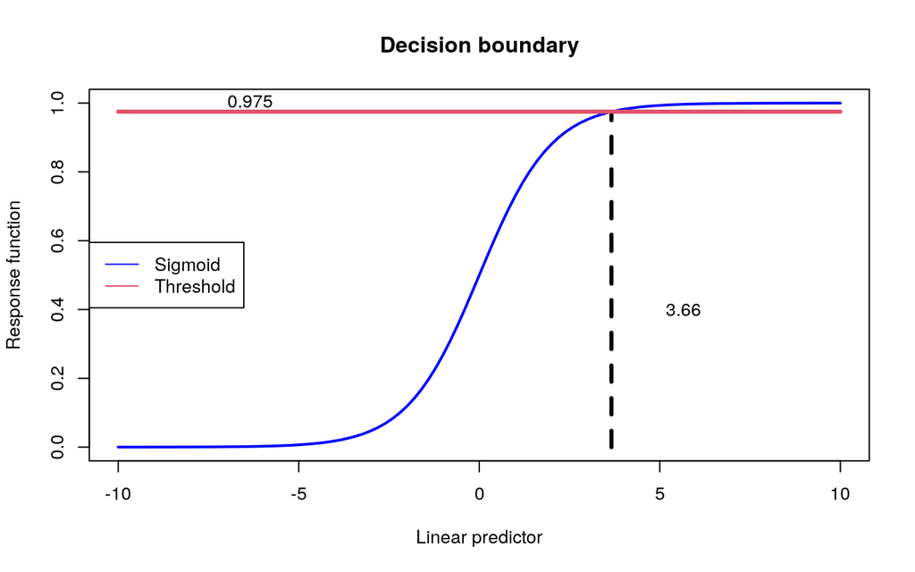

```r
th <- 0.975
lp <- round(log(th/(1-th)),digits=2)
curve({exp(x)/(1+exp(x))}, from=-10, to=10,
      xlab="Linear predictor", ylab="Response function", col="blue", lwd=2,
      main="Decision boundary")
#axis(1, at = c(lp, seq(-10, 10, by = 5)), las=2)
segments(x0=lp,y0=0, x1=lp, y1=th,col=1,lty=2,lwd=3)
segments(x0=-10,y0=th, x1=10, y1=th,col=2,lty=1,lwd=3)
legend("left", c("Sigmoid","Threshold"), lty=c(1,1), col=c("blue",2))
text(x=c(lp+2,lp-10),y=c(0+0.4,0.975+0.03),labels=c(lp, th))
```

## Exercise 3

### Text

Consider again the moths data set of Section 8.4. (a) What happens to the standard error estimates when the poisson family is used in glm() instead of the quasipoisson family? (b) Analyze the P moths, in the same way as the A moths were analyzed. Comment on the effect of transect length.

### Solution

Firstly we recall the results computed in chapter 8:

```r
library(DAAG)
library(lattice)

rbind(Number=table(moths[, 4]), sapply(split(moths[, -4],moths$habitat),apply, 2, sum))
```

```
##        Bank Disturbed Lowerside NEsoak NWsoak SEsoak SWsoak Upperside
## Number    1         7         9      6      3      7      3         5
## meters   21        49       191    254     65    193    116       952
## A         0         8        41     14     71     37     20        28
## P         4        33        17     14     19      6     48         8
```

```r
# take Lowerside habitat as the reference level
moths$habitat <- relevel(moths$habitat, ref="Lowerside")

summary(A.glm <- glm(A ~ habitat + log(meters), family = "quasipoisson", data = moths))
```

```
##
## Call:
## glm(formula = A ~ habitat + log(meters), family = "quasipoisson",
##     data = moths)
##
## Deviance Residuals:
##     Min       1Q   Median       3Q      Max
## -3.5562  -1.4635  -0.0007   0.9248   3.0822
##
## Coefficients:
##                    Estimate Std. Error t value Pr(>|t|)
## (Intercept)         1.20981    0.45530   2.657   0.0122 *
## habitatBank       -16.90566 2096.58841  -0.008   0.9936
## habitatDisturbed   -1.28323    0.64737  -1.982   0.0561 .
## habitatNEsoak      -0.82170    0.53700  -1.530   0.1358
## habitatNWsoak       1.56243    0.33426   4.674 5.11e-05 ***
## habitatSEsoak       0.06206    0.38515   0.161   0.8730
## habitatSWsoak       0.23143    0.47807   0.484   0.6316
## habitatUpperside   -0.16234    0.58429  -0.278   0.7829
## log(meters)         0.12917    0.15278   0.845   0.4041
## ---
## Signif. codes:  0 '***' 0.001 '**' 0.01 '*' 0.05 '.' 0.1 ' ' 1
##
## (Dispersion parameter for quasipoisson family taken to be 2.700801)
##
##     Null deviance: 257.108  on 40  degrees of freedom
## Residual deviance:  93.991  on 32  degrees of freedom
## AIC: NA
##
## Number of Fisher Scoring iterations: 13
```

```r
summary(B.glm <- glm(A ~ habitat + log(meters), family = "poisson", data = moths))
```

```
##
## Call:
## glm(formula = A ~ habitat + log(meters), family = "poisson",
##     data = moths)
##
## Deviance Residuals:
##     Min       1Q   Median       3Q      Max
## -3.5562  -1.4635  -0.0007   0.9248   3.0822
##
## Coefficients:
##                    Estimate Std. Error z value Pr(>|z|)
## (Intercept)         1.20981    0.27705   4.367 1.26e-05 ***
## habitatBank       -16.90566 1275.75387  -0.013  0.98943
## habitatDisturbed   -1.28323    0.39392  -3.258  0.00112 **
## habitatNEsoak      -0.82170    0.32676  -2.515  0.01191 *
## habitatNWsoak       1.56243    0.20340   7.682 1.57e-14 ***
## habitatSEsoak       0.06206    0.23436   0.265  0.79114
## habitatSWsoak       0.23143    0.29090   0.796  0.42628
## habitatUpperside   -0.16234    0.35554  -0.457  0.64796
## log(meters)         0.12917    0.09297   1.389  0.16471
## ---
## Signif. codes:  0 '***' 0.001 '**' 0.01 '*' 0.05 '.' 0.1 ' ' 1
##
## (Dispersion parameter for poisson family taken to be 1)
##
##     Null deviance: 257.108  on 40  degrees of freedom
## Residual deviance:  93.991  on 32  degrees of freedom
## AIC: 226.71
##
## Number of Fisher Scoring iterations: 13
```

1. We can see that in case of the quasi-poisson the dispersion estimate is 2.70. The use of the quasi-poisson has the effect of increasing Standard Errors by a factor $\sqrt{2.70}$ relative to the poisson family. Indeed we should take into account that in *quasi Poisson* the variance is modelled as $Var(y_i) = \phi E[y_i]$ . So the Standard Errors will be reduced by a factor $\sqrt{2.70}$ if the poisson family is used.

```r
#quasi-poisson model
st_A <- signif(unname(summary(A.glm)$coefficients[, 2]), digits = 4)
# poisson model
st_B <- signif(unname(summary(B.glm)$coefficients[, 2]), digits = 4)
factor <- sqrt(2.7)

#reduce quasi-poisson by a factor of sqrt(2.7)
computed_std <- signif(st_A/factor, digits = 4)

df <- data.frame("std_pois" = st_B, "computed_std" = computed_std)
df
```

```
##    std_pois computed_std
## 1 2.770e-01    2.771e-01
## 2 1.276e+03    1.276e+03
## 3 3.939e-01    3.940e-01
## 4 3.268e-01    3.268e-01
## 5 2.034e-01    2.034e-01
## 6 2.344e-01    2.344e-01
## 7 2.909e-01    2.910e-01
## 8 3.555e-01    3.556e-01
## 9 9.297e-02    9.299e-02
```

This results show that, less than some approximation, the standard error of the poisson model is reduced just by the factor $\sqrt{2.70}$, as we stated before.

2. Let’s analyze the P moths:

```r
library(DAAG)
library(lattice)

#Tabular summary of number of moths of species P by habitat
sapply(split(moths$P, moths$habitat),sum)
```

```
## Lowerside      Bank Disturbed    NEsoak    NWsoak    SEsoak    SWsoak Upperside
##        17         4        33        14        19         6        48         8
```

```r
# take Lowerside habitat as the reference level
moths$habitat <- relevel(moths$habitat, ref="Lowerside")
summary(P.glm <- glm(P ~ habitat + log(meters), family=quasipoisson, data=moths))
```

```
##
## Call:
## glm(formula = P ~ habitat + log(meters), family = quasipoisson,
##     data = moths)
##
## Deviance Residuals:
##     Min       1Q   Median       3Q      Max
## -2.9479  -1.3155  -0.4167   0.5660   2.9719
##
## Coefficients:
##                  Estimate Std. Error t value Pr(>|t|)
## (Intercept)       -0.8608     0.6745  -1.276  0.21105
## habitatBank        0.5569     0.8837   0.630  0.53301
## habitatDisturbed   1.4364     0.5172   2.777  0.00909 **
## habitatNEsoak     -0.3211     0.5844  -0.549  0.58651
## habitatNWsoak      1.0106     0.5309   1.904  0.06598 .
## habitatSEsoak     -1.0697     0.7560  -1.415  0.16673
## habitatSWsoak      1.6383     0.4582   3.575  0.00113 **
## habitatUpperside  -1.5773     0.7757  -2.033  0.05038 .
## log(meters)        0.5552     0.1759   3.157  0.00347 **
## ---
## Signif. codes:  0 '***' 0.001 '**' 0.01 '*' 0.05 '.' 0.1 ' ' 1
##
## (Dispersion parameter for quasipoisson family taken to be 2.527554)
##
##     Null deviance: 217.819  on 40  degrees of freedom
## Residual deviance:  76.924  on 32  degrees of freedom
## AIC: NA
##
## Number of Fisher Scoring iterations: 6
```

The model has the form
$$y = \mathbf{\beta^{\dagger}_{\mathsf{habitat}}\mathsf{habitat}}+\beta_{\mathsf{meters}} \log(\mathsf{meters})$$
where $y = \log(\mathsf{P})$ and P is the expected number of moths.

According to the model:
$$\log(\mathsf{P}) = -0.86+0.56 \log(\mathsf{meters})+ \mathbf{\beta^{\dagger}_{\mathsf{habitat}}\mathsf{habitat}}$$
which is equivalent to:
$$\begin{aligned}
\mathsf{P} &= \exp(-0.86+0.56 \log(\mathsf{meters})+ \mathbf{\beta^{\dagger}_{\mathsf{habitat}}\mathsf{habitat}}) \\
&= 0.42 \times \mathsf{meters}^{0.56}\times e^{\mathbf{\beta^{\dagger}_{\mathsf{habitat}}\mathsf{habitat}}} \\
&\simeq 0.42 \times \sqrt{\mathsf{meters}}\times e^{\mathbf{\beta^{\dagger}_{\mathsf{habitat}}\mathsf{habitat}}}
\end{aligned}$$
The above output indicates that moths of species P are more abundant in $\texttt{SWsoak}$ and in $\texttt{Disturbed}$. The number of moths of species P increases with transect length, approximately as $\sqrt{meters}$.

## Exercise 6

### Text:

As in the previous exercise, the function poissonsim() allows for experimentation with Poisson regression. In particular, poissonsim() can be used to simulate Poisson responses with log-rates equal to a + bx, where a and b are fixed values by default.

```r
set.seed(343)
x <- seq(from=0, to=1, by=0.01)
```

1. Compared to the true values (2,-4) the estimated coefficients are quite closed to them, so the estimation is good.

```r
sim_a <- poissonsim(x)
y_a <- sim_a$y
glm(y_a ~ x, family=poisson)
```

```
##
## Call:  glm(formula = y_a ~ x, family = poisson)
##
## Coefficients:
## (Intercept)            x
##       1.826       -3.622
##
## Degrees of Freedom: 100 Total (i.e. Null);  99 Residual
## Null Deviance:       221.6
## Residual Deviance: 78.86     AIC: 260.4
```

```r
sim_b <- poissonsim(x, slope.sd=5)
y_b <- sim_b$y
glm(y_b ~ x, family=poisson)
```

```
##
## Call:  glm(formula = y_b ~ x, family = poisson)
##
## Coefficients:
## (Intercept)            x
##       2.120        1.739
##
## Degrees of Freedom: 100 Total (i.e. Null);  99 Residual
## Null Deviance:       11390
## Residual Deviance: 10850     AIC: 11090
```

```r
glm(y_b ~ x, family=quasipoisson)
```

```
##
## Call:  glm(formula = y_b ~ x, family = quasipoisson)
##
## Coefficients:
## (Intercept)            x
##       2.120        1.739
##
## Degrees of Freedom: 100 Total (i.e. Null);  99 Residual
## Null Deviance:       11390
## Residual Deviance: 10850     AIC: NA
```